# 05_sin_mid

## 05_sin_mid

#### Question

1. Below, on the $ty$ plane, is a graph of $y=\sin(t)+k$ with a random parameter $k$ and, as a dotted line, the parent function $y=\sin(t)$.

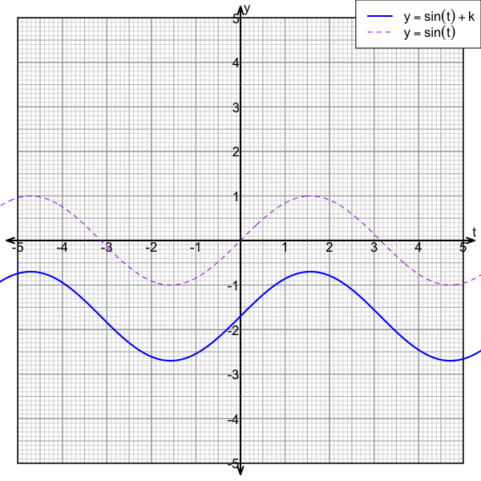

   What is the value of $k$?

#### Question

2. Below, on the $ty$ plane, is a graph of $y=\sin(t)+k$ with a random parameter $k$ and, as a dotted line, the parent function $y=\sin(t)$.

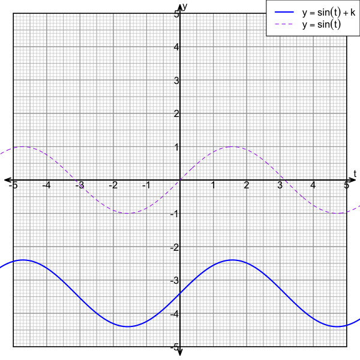

   What is the value of $k$?

#### Question

3. Below, on the $ty$ plane, is a graph of $y=\sin(t)+k$ with a random parameter $k$ and, as a dotted line, the parent function $y=\sin(t)$.

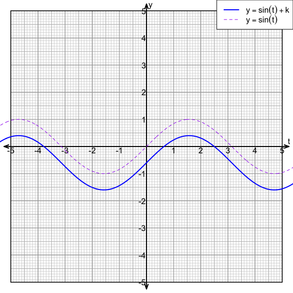

   What is the value of $k$?

#### Question

4. Below, on the $ty$ plane, is a graph of $y=\sin(t)+k$ with a random parameter $k$ and, as a dotted line, the parent function $y=\sin(t)$.

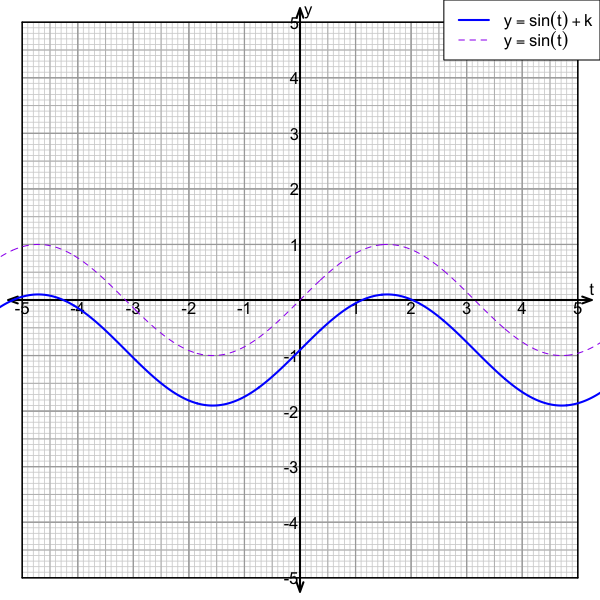

   What is the value of $k$?

#### Question

5. Below, on the $ty$ plane, is a graph of $y=\sin(t)+k$ with a random parameter $k$ and, as a dotted line, the parent function $y=\sin(t)$.

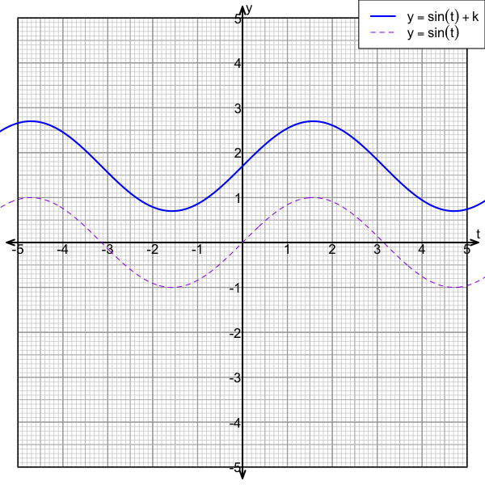

   What is the value of $k$?

#### Question

6. Below, on the $ty$ plane, is a graph of $y=\sin(t)+k$ with a random parameter $k$ and, as a dotted line, the parent function $y=\sin(t)$.

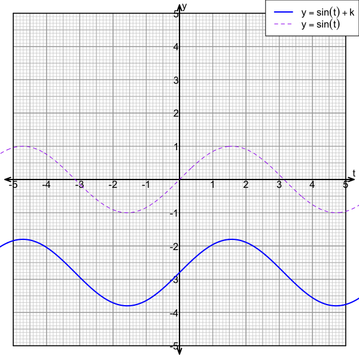

   What is the value of $k$?

#### Question

7. Below, on the $ty$ plane, is a graph of $y=\sin(t)+k$ with a random parameter $k$ and, as a dotted line, the parent function $y=\sin(t)$.

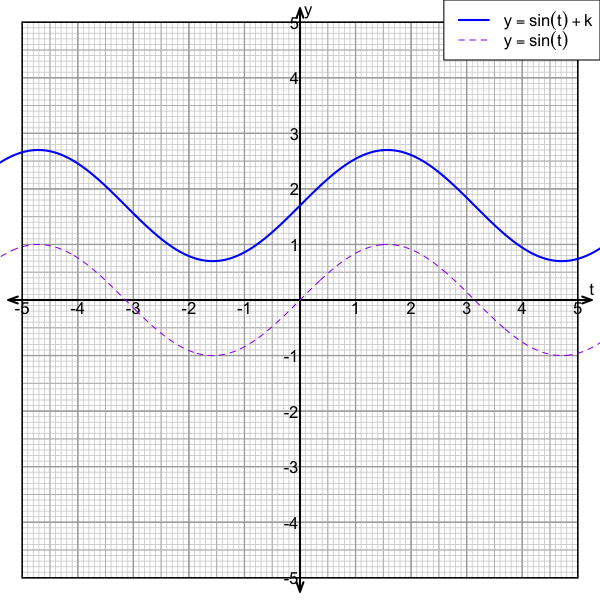

   What is the value of $k$?

#### Question

8. Below, on the $ty$ plane, is a graph of $y=\sin(t)+k$ with a random parameter $k$ and, as a dotted line, the parent function $y=\sin(t)$.

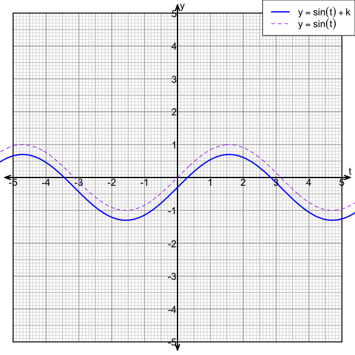

   What is the value of $k$?